# Extended evaluation of differential chromatin interaction detection analysis using simulated Hi-C data

John Stansfield, Mikhail Dozmorov

# Introduction

To evaluate the performance of different normalization methods on the detection of chromatin interaction differences, controlled changes were used. To better control for existing differences in the real Hi-C data, simulated Hi-C datasets were used. The data was simulated using the `hic_simulate` function. For the simulated matrices, the default values were used (see `?hic_simulate`) except for changing the size to be a 250 x 250 matrix. The effect of varying fold changes (1.5 by default) and varying number of controlled changes (500 by default) is investigated.

Fold changes are applied to one of the datasets by upregulating the selected IF if the difference between the datasets is positive. If the difference between the datasets at that point is negative the IF is downregulated by the specified fold change. This method of making changes ensures that the fold change specified is actually realized on the MD plot.

## The effect of fold change

### 1.5 Fold change

|  | loess | chromoR | ice | kr | scn |
| --- | --- | --- | --- | --- | --- |
| true positive | 112 | 22 | 87 | 89 | 68 |
| false positive | 1060 | 1440 | 1090 | 1130 | 1140 |
| true negative | 24800 | 29400 | 24100 | 24800 | 24700 |
| false negative | 388 | 478 | 396 | 411 | 432 |
| Total | 26400 | 31400 | 25700 | 26400 | 26400 |
| TPR | 0.224 | 0.044 | 0.18 | 0.178 | 0.136 |
| SPC | 0.959 | 0.953 | 0.957 | 0.957 | 0.956 |
| F1 | 0.972 | 0.968 | 0.97 | 0.97 | 0.969 |
| AUC | 0.749 | 0.503 | 0.667 | 0.669 | 0.624 |
| AUC 20% | 0.0768 | 0.0201 | 0.0614 | 0.0608 | 0.0471 |

[output cut: 7 more lines]

### 2.0 Fold change

|  | loess | chromoR | ice | kr | scn |
| --- | --- | --- | --- | --- | --- |
| true positive | 287 | 33 | 200 | 201 | 143 |
| false positive | 890 | 1430 | 985 | 1020 | 1070 |
| true negative | 25100 | 29400 | 24300 | 24900 | 24900 |
| false negative | 213 | 467 | 289 | 299 | 357 |
| Total | 26500 | 31400 | 25700 | 26500 | 26500 |
| TPR | 0.574 | 0.066 | 0.409 | 0.402 | 0.286 |
| SPC | 0.966 | 0.954 | 0.961 | 0.961 | 0.959 |
| F1 | 0.978 | 0.969 | 0.974 | 0.974 | 0.972 |
| AUC | 0.912 | 0.516 | 0.785 | 0.785 | 0.727 |
| AUC 20% | 0.141 | 0.0251 | 0.101 | 0.1 | 0.0806 |

[output cut: 7 more lines]

### 4.0 Fold change

|  | loess | chromoR | ice | kr | scn |
| --- | --- | --- | --- | --- | --- |
| true positive | 483 | 56 | 421 | 432 | 402 |
| false positive | 700 | 1400 | 754 | 783 | 807 |
| true negative | 25200 | 29500 | 24200 | 25100 | 25100 |
| false negative | 17 | 444 | 66 | 68 | 98 |
| Total | 26400 | 31400 | 25500 | 26400 | 26400 |
| TPR | 0.966 | 0.112 | 0.864 | 0.864 | 0.804 |
| SPC | 0.973 | 0.955 | 0.97 | 0.97 | 0.969 |
| F1 | 0.986 | 0.97 | 0.983 | 0.983 | 0.982 |
| AUC | 0.993 | 0.488 | 0.968 | 0.967 | 0.958 |
| AUC 20% | 0.194 | 0.0232 | 0.179 | 0.179 | 0.171 |

[output cut: 7 more lines]

### 10.0 fold change

|  | loess | chromoR | ice | kr | scn |
| --- | --- | --- | --- | --- | --- |
| true positive | 483 | 82 | 475 | 484 | 476 |
| false positive | 710 | 1390 | 722 | 735 | 746 |
| true negative | 25300 | 29500 | 24700 | 25200 | 25200 |
| false negative | 17 | 418 | 17 | 16 | 24 |
| Total | 26500 | 31400 | 25900 | 26500 | 26500 |
| TPR | 0.966 | 0.164 | 0.965 | 0.968 | 0.952 |
| SPC | 0.973 | 0.955 | 0.972 | 0.972 | 0.971 |
| F1 | 0.986 | 0.97 | 0.985 | 0.985 | 0.985 |
| AUC | 0.995 | 0.543 | 0.994 | 0.994 | 0.99 |
| AUC 20% | 0.195 | 0.0424 | 0.194 | 0.194 | 0.192 |

[output cut: 7 more lines]

### Bar plots

The bar plots show comparisons of the effect of different fold changes using fixed numbers of controlled changes on different performance metrics.

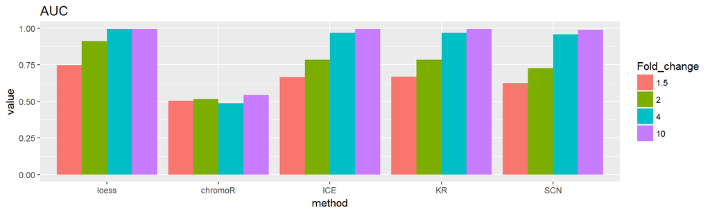

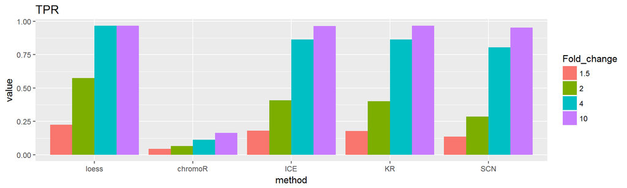

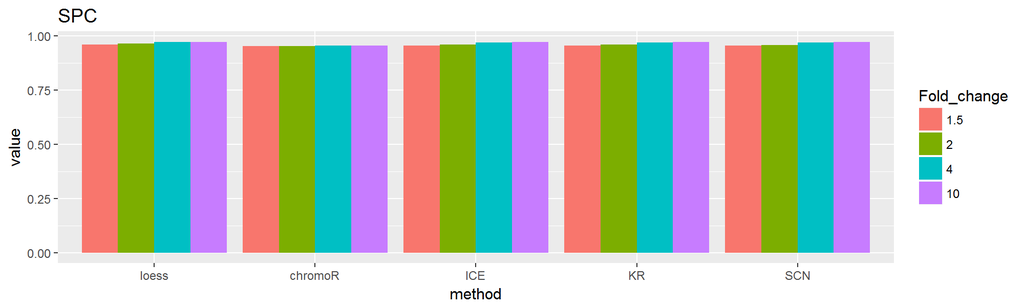

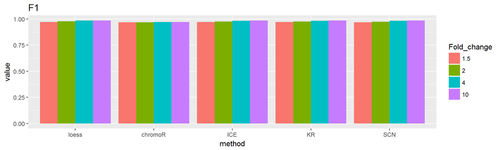

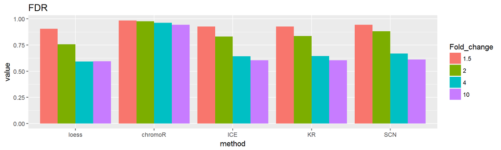

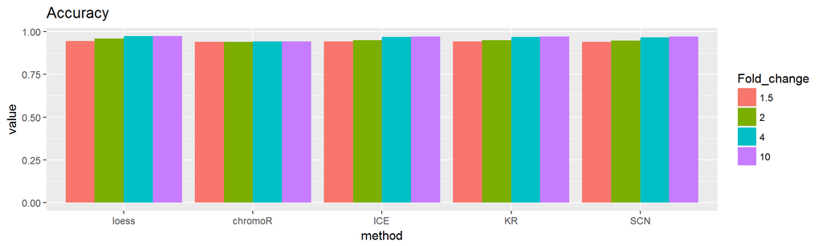

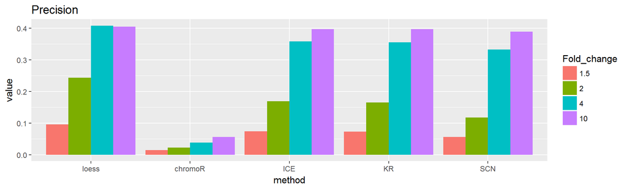

## The effect of introduced number of changes

A specified number of interaction frequencies were increased or decreased to produce a 1.5-fold change.

### 1 change

|  | loess | chromoR | ice | kr | scn |
| --- | --- | --- | --- | --- | --- |
| true positive | 0 | 0 | 0 | 0 | 0 |
| false positive | 1160 | 1460 | 1200 | 1220 | 1220 |
| true negative | 25300 | 29900 | 24900 | 25300 | 25300 |
| false negative | 1 | 1 | 1 | 1 | 1 |
| Total | 26500 | 31400 | 26100 | 26500 | 26500 |
| TPR | 0 | 0 | 0 | 0 | 0 |
| SPC | 0.956 | 0.953 | 0.954 | 0.954 | 0.954 |
| F1 | 0.978 | 0.976 | 0.977 | 0.976 | 0.976 |
| AUC | 0.876 | 0.788 | 0.819 | 0.83 | 0.828 |
| AUC 20% | 0.0756 | 0 | 0.0189 | 0.0301 | 0.0283 |

[output cut: 7 more lines]

### 100 changes

|  | loess | chromoR | ice | kr | scn |
| --- | --- | --- | --- | --- | --- |
| true positive | 23 | 3 | 16 | 18 | 14 |
| false positive | 1140 | 1450 | 1140 | 1190 | 1190 |
| true negative | 25000 | 29800 | 24300 | 25000 | 25000 |
| false negative | 77 | 97 | 82 | 82 | 86 |
| Total | 26300 | 31400 | 25600 | 26300 | 26300 |
| TPR | 0.23 | 0.03 | 0.163 | 0.18 | 0.14 |
| SPC | 0.956 | 0.954 | 0.955 | 0.955 | 0.954 |
| F1 | 0.976 | 0.975 | 0.975 | 0.975 | 0.975 |
| AUC | 0.735 | 0.537 | 0.63 | 0.63 | 0.578 |
| AUC 20% | 0.0723 | 0.026 | 0.0464 | 0.0479 | 0.0401 |

[output cut: 7 more lines]

### 200 changes

|  | loess | chromoR | ice | kr | scn |
| --- | --- | --- | --- | --- | --- |
| true positive | 45 | 9 | 37 | 43 | 41 |
| false positive | 1130 | 1460 | 1140 | 1170 | 1170 |
| true negative | 25100 | 29700 | 24200 | 25100 | 25100 |
| false negative | 155 | 191 | 154 | 157 | 159 |
| Total | 26400 | 31400 | 25500 | 26400 | 26400 |
| TPR | 0.225 | 0.045 | 0.194 | 0.215 | 0.205 |
| SPC | 0.957 | 0.953 | 0.955 | 0.955 | 0.955 |
| F1 | 0.975 | 0.973 | 0.974 | 0.974 | 0.974 |
| AUC | 0.763 | 0.501 | 0.677 | 0.681 | 0.652 |
| AUC 20% | 0.0785 | 0.0225 | 0.0612 | 0.0623 | 0.0573 |

[output cut: 7 more lines]

### 1000 changes

|  | loess | chromoR | ice | kr | scn |
| --- | --- | --- | --- | --- | --- |
| true positive | 235 | 48 | 163 | 168 | 134 |
| false positive | 940 | 1420 | 1010 | 1030 | 1080 |
| true negative | 24400 | 28900 | 23600 | 24300 | 24200 |
| false negative | 765 | 952 | 802 | 832 | 866 |
| Total | 26300 | 31400 | 25600 | 26300 | 26300 |
| TPR | 0.235 | 0.048 | 0.169 | 0.168 | 0.134 |
| SPC | 0.963 | 0.953 | 0.959 | 0.959 | 0.957 |
| F1 | 0.966 | 0.961 | 0.963 | 0.963 | 0.961 |
| AUC | 0.735 | 0.511 | 0.639 | 0.636 | 0.599 |
| AUC 20% | 0.0716 | 0.0233 | 0.0542 | 0.0543 | 0.0439 |

[output cut: 7 more lines]

### 5000 changes

|  | loess | chromoR | ice | kr | scn |
| --- | --- | --- | --- | --- | --- |
| true positive | 555 | 225 | 519 | 534 | 445 |
| false positive | 630 | 1240 | 671 | 687 | 762 |
| true negative | 20900 | 25100 | 20400 | 20800 | 20700 |
| false negative | 4440 | 4770 | 4360 | 4470 | 4560 |
| Total | 26500 | 31400 | 26000 | 26500 | 26500 |
| TPR | 0.111 | 0.045 | 0.106 | 0.107 | 0.089 |
| SPC | 0.971 | 0.953 | 0.968 | 0.968 | 0.965 |
| F1 | 0.892 | 0.893 | 0.89 | 0.89 | 0.886 |
| AUC | 0.679 | 0.518 | 0.603 | 0.601 | 0.575 |
| AUC 20% | 0.0544 | 0.0231 | 0.0448 | 0.0442 | 0.0372 |

[output cut: 7 more lines]

### Bar plots

Below are bar plots showing comparisons of the different normalization methods over the varying numbers of changes at a fixed fold change for selected metrics.

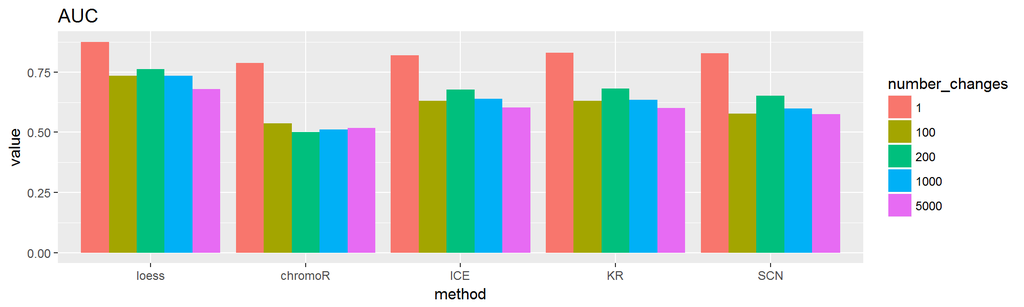

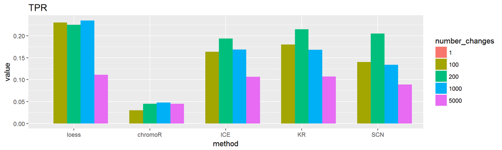

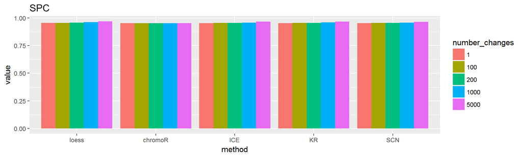

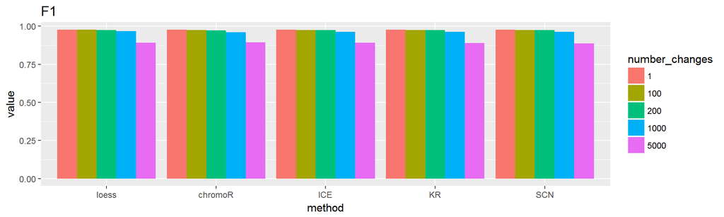

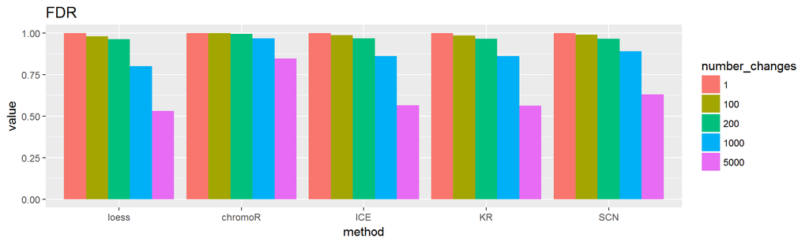

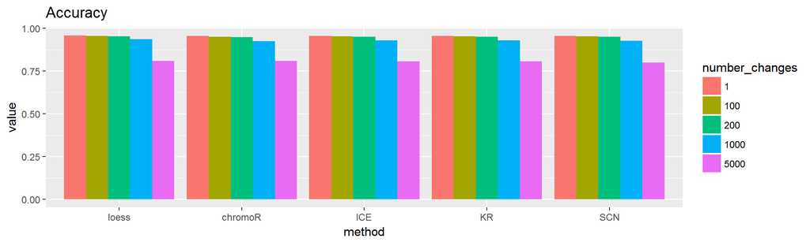

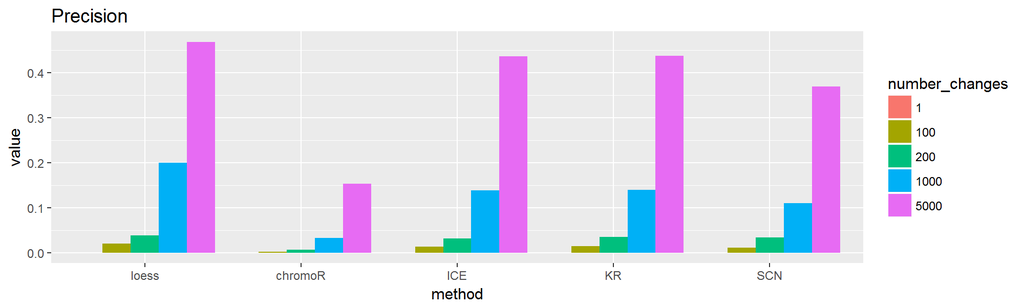